# Understanding Migration Patterns in Bolivia

Wesley Ordonez

2023-08-18

## Overview

### A Google Data Analytics Capstone Project

This report is the culmination of a rigorous journey through Google’s Data Analytics Professional Certificate Program. It represents the final capstone project, an opportunity to apply the wide array of skills and knowledge acquired throughout the course. Unlike the other projects within the program, this capstone project is self-directed, providing an avenue to independently navigate the entire data analytics process, from data collection to visualization and insights generation.

## Executive Summary

This research was undertaken to delve into the displacement and migration patterns observed within Bolivia, with a special emphasis on the influx into the department of Santa Cruz. The motivating force behind this investigation is Santa Cruz’s remarkable growth rate, which has significant implications for resource management, sociopolitical stability, and cultural preservation.

Our primary objective is to chart the migratory paths of individuals, pinpointing their residences five years prior and understanding the motivations driving their relocation, particularly towards Santa Cruz. The study leverages data from the 2021 Survey for Homes of Bolivia, providing a comprehensive snapshot of Bolivian migratory habits.

However, understanding migration in isolation only tells part of the story. To paint a holistic picture of growth dynamics in Santa Cruz and Bolivia as a whole, we also explore various socioeconomic indicators, including income levels, gender and civil statuses, and labor statistics.

Our principal stakeholders include the city of Santa Cruz, municipal and political leaders, economists, urban planners, business leaders, and cultural advocates. This research equips them with a crucial tool to facilitate informed decision-making, whether it’s in the realm of urban planning, policy-making, economic initiatives, or cultural programs.

Guided by insights drawn from robust statistical data, we present our findings as a clear roadmap to navigate potential growth challenges. The ultimate goal is to support Santa Cruz and its stakeholders in steering the city towards a future that is not just sustainable, but also inclusive.

As you delve into the report, you’ll encounter our detailed analyses and key findings, which shed light on the intricacies of migration patterns and their implications for Bolivia’s socio-cultural and economic landscape.

## Preparation

### Data Sourcing

The primary data source for this study is the “Survey of Homes 2021”, conducted by Bolivia’s National Institute of Statistics (NIS). The survey serves as a comprehensive repository of responses collected from across all departments in Bolivia, encompassing a wide range of topics including homeownership, labor, education, and migration. With a total of 12,948 homes surveyed, it offers a rich dataset for exploring the country’s migratory patterns.

This survey was accessed through the Archivo Nacional de Datos (ANDA) Catalogue, a centralized data and microdata repository. The ANDA Catalogue is backed by the NIS, in collaboration with the Ministerio de Planificacion del Desarollo del Estado Plurinacional de Bolivia, reinforcing the credibility and reliability of the survey data used in this study.

### Formatting

The original data from the “Survey of Homes 2021” was provided in SPSS format, a proprietary file format from IBM’s statistical software. To facilitate a more streamlined analysis, the data was converted into a CSV (Comma Separated Values) file, a universally accepted format for data manipulation and analysis.

This reformatted dataset comprises 357 variables across 42,090 rows, each row representing a unique response in the survey. These variables encompass diverse aspects related to homeownership, labor, education, and migration, offering a comprehensive dataset for the investigation of migratory patterns in Bolivia.

## Processing

Processing the data involved several steps to ensure it was ready for analysis:

#### Variable Reduction:

The number of variables was reduced from 357 to 18. These essential variables include factors like sex, education, labor, income, and migratory history. This selection was based on their relevance to the research question and their potential to yield meaningful insights.

#### Data Conversion:

The data, originally purely numerical, was converted into readable strings for ease of analysis. This was achieved using the dictionary/key information provided with the dataset.

#### Translation and Renaming:

For ease of readability and analysis, effort was dedicated to translating and renaming variable names and a few text/string rows.

#### Libraries and Tools Used:

During this processing phase, several libraries were utilized:

- rmarkdown: For dynamic report generation in R.
- haven: For importing and exporting SPSS, Stata, and SAS files.
- skimr: For providing summary statistics.
- janitor: For simple data cleaning.
- tidyr: For tidying data.
- dplyr: For data manipulation.
- ggplot2: For creating plots.
- stringr: For string manipulation.
- kable: For table formatting

These libraries played a crucial role in refining and preparing the data for subsequent analysis.

## Analysis

### Preliminary Analysis

In the initial phase of the analysis, the focus is on gaining a high-level understanding of the data. This involves exploring the distribution of responses across different departments, examining variables such as sex and population type, and identifying any potential trends or patterns that warrant further investigation.

Each figure in this section is accompanied by a brief caption that summarizes its key findings and significance. The code used to generate these figures is available upon request, allowing technically inclined readers to reproduce or extend the analysis.

#### Geographic Distribution

The initial step in the analysis was to understand the geographic distribution of responses. The first plot (Figure 1) presents a bar chart of the total number of survey responses by department.

This visualization provides a high-level overview of where the survey responses are coming from. It’s important to consider the distribution of responses across departments when analyzing the data, as uneven distribution could introduce bias towards larger departments with higher response counts.

As shown in Figure 1, the departments of La Paz, Santa Cruz, and Cochabamba have the highest number of responses, while other departments have fewer responses. This distribution is an essential context for the subsequent analysis.

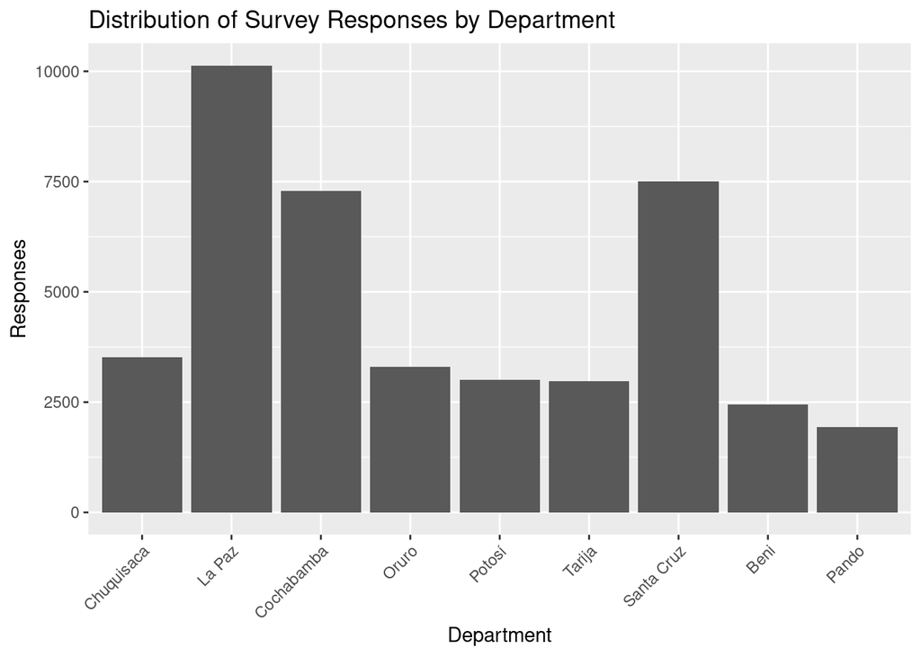

Figure 1: Distribution of Survey Responses by Department

The top three departments with the highest number of responses - La Paz, Santa Cruz, and Cochabamba - provided 10,129, 7,499, and 7,289 responses respectively. This distribution sets the stage for a more detailed breakdown by gender, as presented in the next section.

#### Distribution of Sex and Population Type

The next step was to examine the distribution of responses when separated by sex and population type. This disaggregation allows us to understand if there are any significant differences in response rates among these categories, which could be indicative of different migratory patterns or behaviors.

The two plots in this section (Figures 2 and 3) present the distribution of responses by sex and population type, respectively, across the different departments.

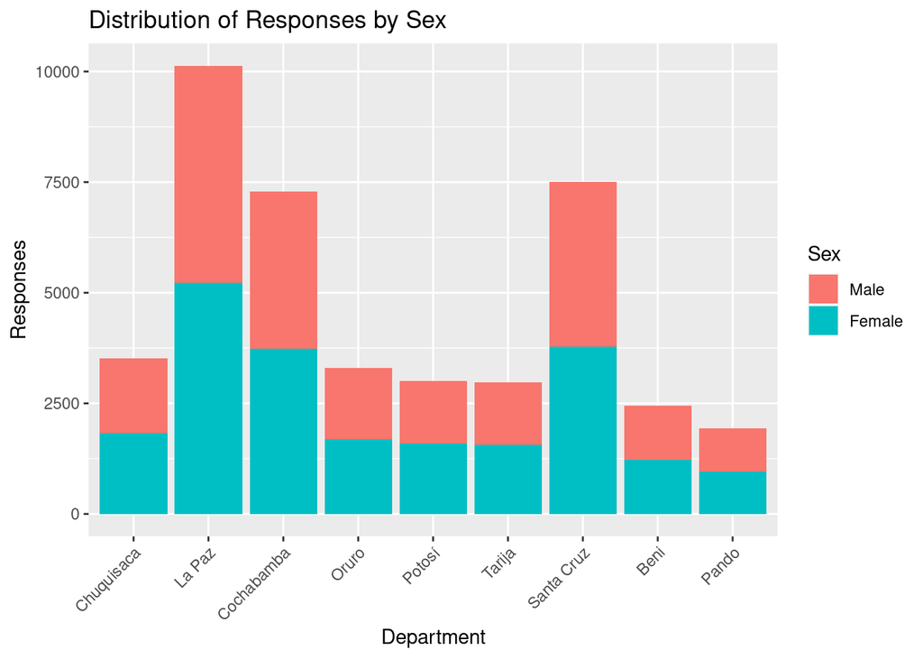

Figure 2: Distribution of Survey Responses by Sex

This plot shows a relatively equal distribution of survey responses by sex across each department.

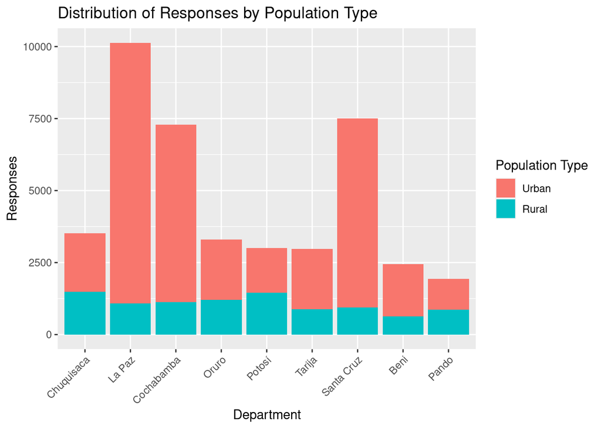

Figure 3: Distribution of Survey Responses by Population Type

This plot presents the distribution of survey responses by population type (urban/rural) across each department. The the most populous departments (Cochabamba, La Paz, and Santa Cruz) have the highest discrepancy between population types, favoring urbanism. Pando and Chuquisaca on the other hand, have almost equal distribution of rural and urban populations.

#### Distribution of Average Age

The next facet of the analysis examines the age distribution of the respondents. Understanding the age distribution is crucial as it can shed light on whether the responses reflect the age demographics of Bolivia’s population and if there are distinct migratory behaviors associated with different age groups.

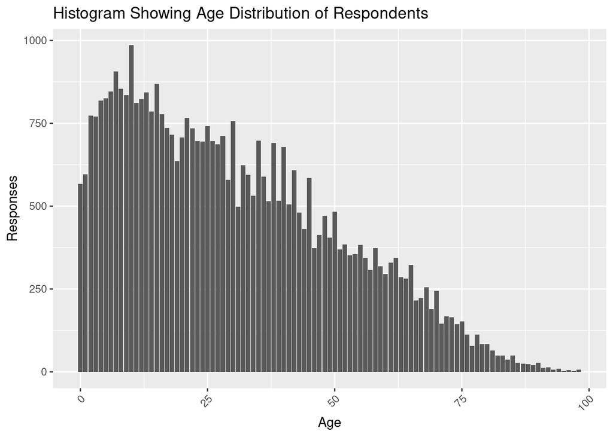

Figure 4: Age Distribution of Survey Respondents

##### Zero-Age Analysis

There’s a considerable amount of responses with zero age. This would be a count of infants in each household. A quick analysis is needed to show the impact those responses will have on the study.

The initial analysis shows the range of ages goes from 0 to 98 years. There are 567 entries with zero-age. The next figure shows the distribution of those zero-age responses, normalized as a percentage of the total responses of each department.

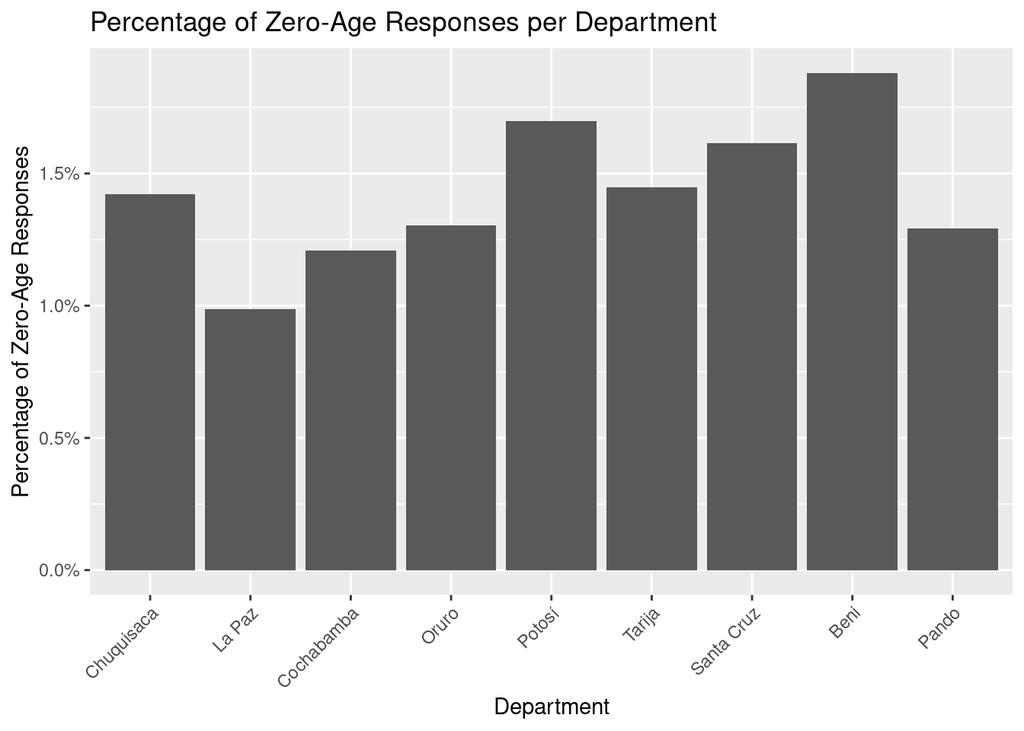

Figure 5: Percentage of Zero-Age Responses per Department

As this plot shows, no department has more than 2% of their responses with zero-age. As a demonstration, the average age of Santa Cruz respondents including the zero-age responses is 28.88 years. The average age removing the zero-age responses is 29.35 years, which is only 0.47 years more, a negligible amount.

#### Distribution of Age (cont.)

This next figure will show the average age of each department. Migratory patterns of each department may be impacted by the age of the respondents.

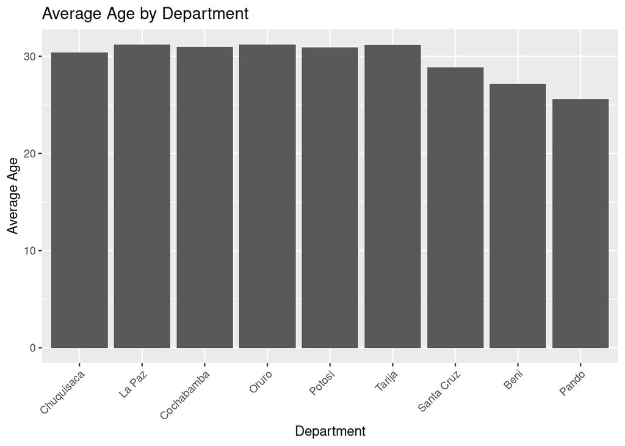

Figure 6: Average Age of Respondents by Department

#### Distribution of Education Levels

A key dimension in understanding home change patterns in Bolivia is education. Education level can significantly influence an individual’s opportunities and decisions, potentially affecting their likelihood to migrate. In this section of the analysis, we explore the distribution of education levels among survey respondents to gain insights into their educational demographics.

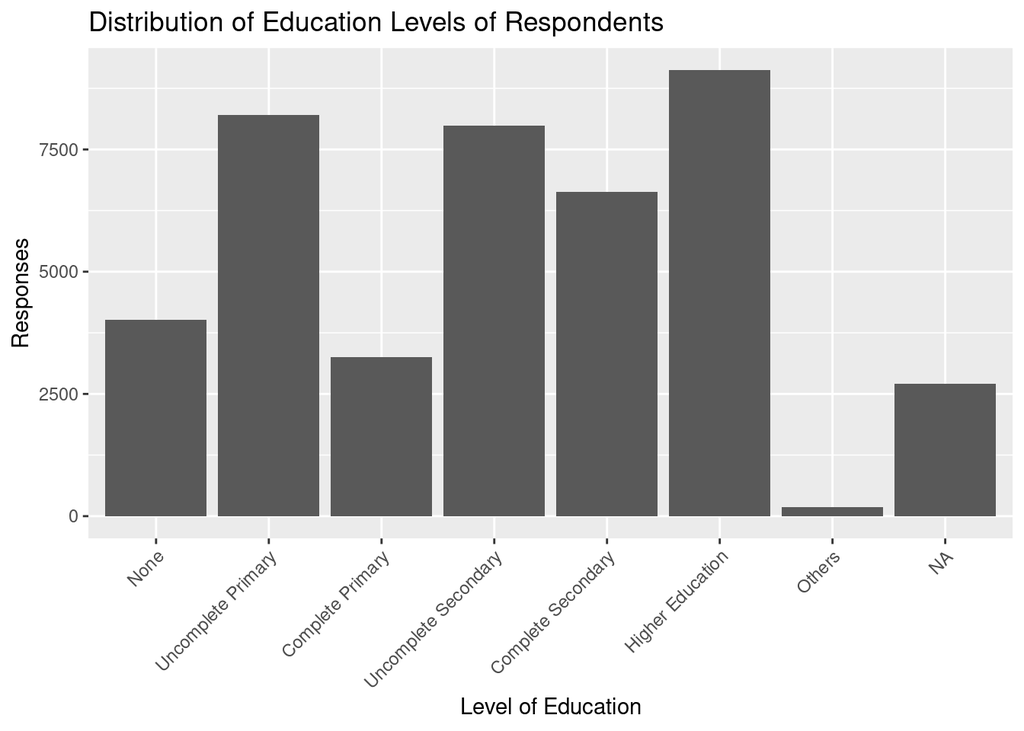

Figure 7: Distribution of Education Levels Among Respondents

Across all respondents, ‘higher’ education is the most common level, followed by ‘uncompleted primary’ and ‘uncompleted secondary’. The least common levels are ‘other’ and ‘completed primary’. This distribution suggests a predominantly secondary-educated population among those migrating. It also highlights the strikingly high representation of respondents with ‘uncompleted primary’ education, that begs for further analysis.

Consequently, an important consideration is the age of respondents. In many contexts, individuals under the age of 18 are likely to be still in the process of education, which could affect the distribution of education levels. To account for this, we examine the distribution of education levels among adult respondents, defined as those aged 18 and over.

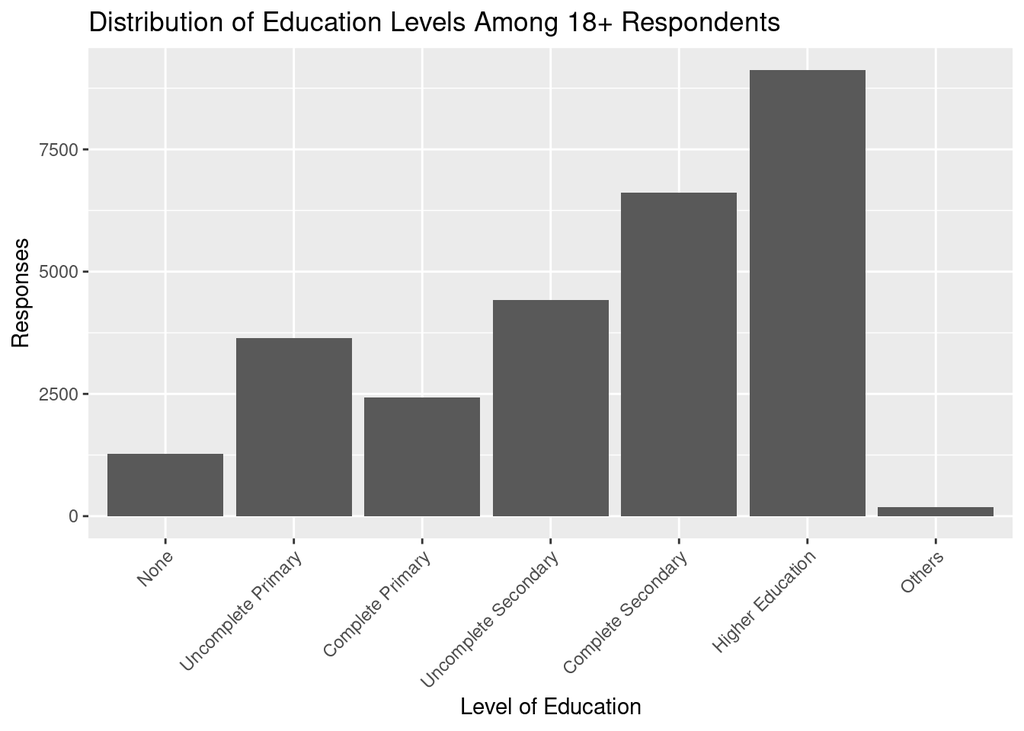

Figure 8: Distribution of Education Levels Among Adult (18+) Respondents

Among adult respondents, the distribution of education levels is similar to the overall population, with ‘higher’ education being the most common level. This consistency underscores the prevalence of secondary education among adults in Bolivia. Nevertheless, ‘uncomplete primary’ and ‘none’ remain relatively high, albeit, greatly reduced in adults, further reinforcing the potential differences in home change patterns among these education groups.

Having examined the overall distribution of education levels and the variation among adult respondents, it’s valuable to further disaggregate the data by sex. Sex can play a significant role in educational attainment due to various societal, cultural, and economic factors. Therefore, understanding the differences in education levels between men and women can provide deeper insights into this data. In the following figure, we will explore the distribution of education levels, comparing male and female respondents to identify any notable trends or disparities.

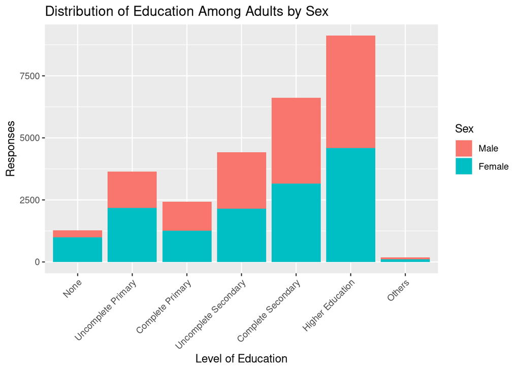

Figure 9: Distribution of Education Levels Among Adults by Sex

Interestingly, the ‘no education’ category, although less common overall, shows a higher female representation. This observation warrants a closer look. The following section delves into a sub-analysis to understand the factors contributing to the female dominance in the ‘no education’ category, exploring potential societal, economic, or cultural influences that might be at play.

##### Investigation of Female Dominance with No-Education Reported

Given the observed higher representation of females in the ‘no education’ category, it’s important to further investigate potential contributing factors. One such factor could be the population type - urban or rural - of the respondents. In many societies, especially in rural areas, educational opportunities can be gender-biased due to prevailing cultural norms. Consequently, we might find that the ‘no education’ category is more prevalent among females in rural areas.

In the next figure, we narrow our focus to the ‘no education’ category and compare the population types of the respondents. This analysis aims to explore whether the population type plays a role in the observed gender disparity in this education level.

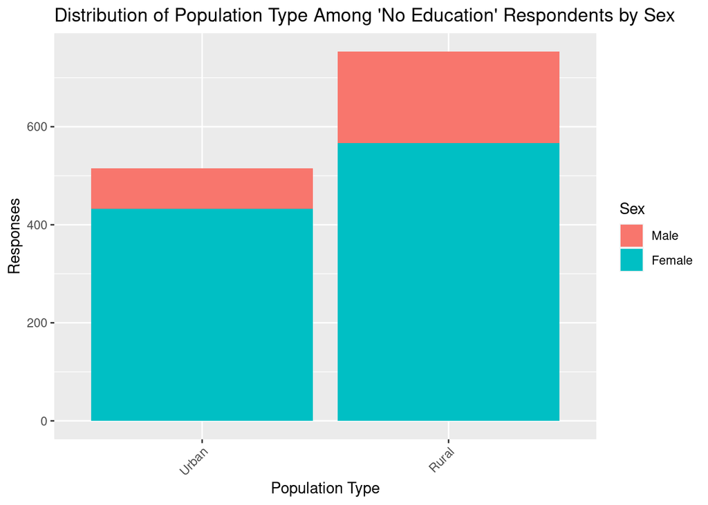

Figure 10: Distribution of Population Type Among ‘No Education’ Respondents by Sex

Another factor that could be influencing this disparity is whether respondents belong to an indigenous group. Indigenous populations often face different socio-economic dynamics and may have unique educational challenges that could impact the gender distribution in the ‘no education’ category.

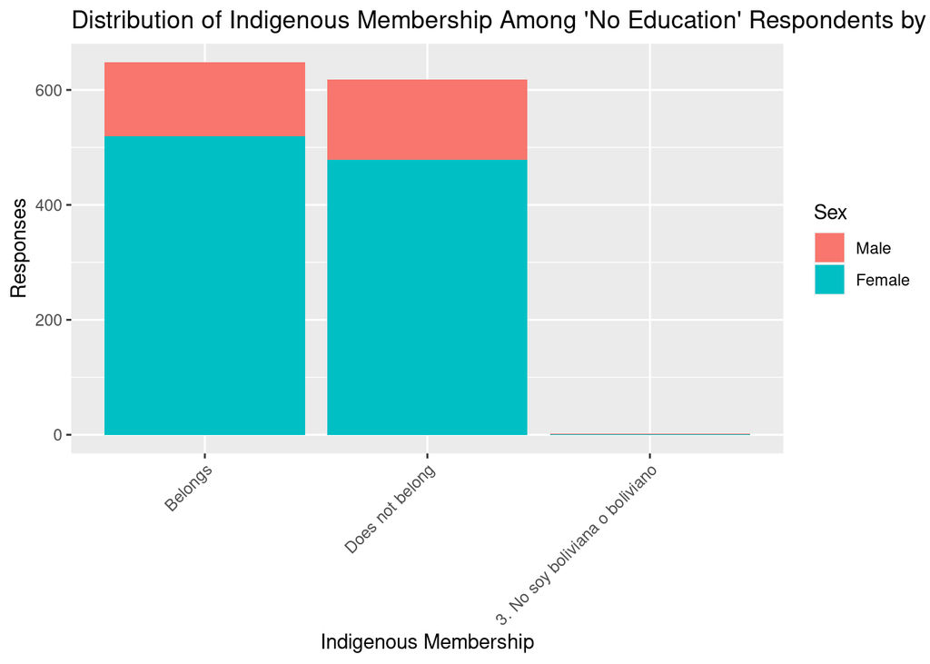

Figure 11: Distribution of Indigenous Group Membership Among ‘No Education’ Respondents by Sex

Examining the distribution of indigenous membership by sex, among respondents with no education, we find minimal difference between the two. This finding suggests there is no discernable influence of the indigenous background to access education, however, deeper analysis and investigation is needed to address the disparity of gender with no education.

#### Distribution of Education Levels (cont.)

As we continue to explore the relationship between education levels and migratory patterns in Bolivia, it’s essential to consider the geographic element. Bolivia’s diverse departments each carry unique socio-economic contexts that could influence education levels and, consequently, migratory behaviors. In this next section of our analysis, we break down the distribution of education levels by department. This inter-departmental examination will allow us to identify any regional trends or disparities in education among respondents, potentially shedding light on region-specific factors impacting migratory patterns.

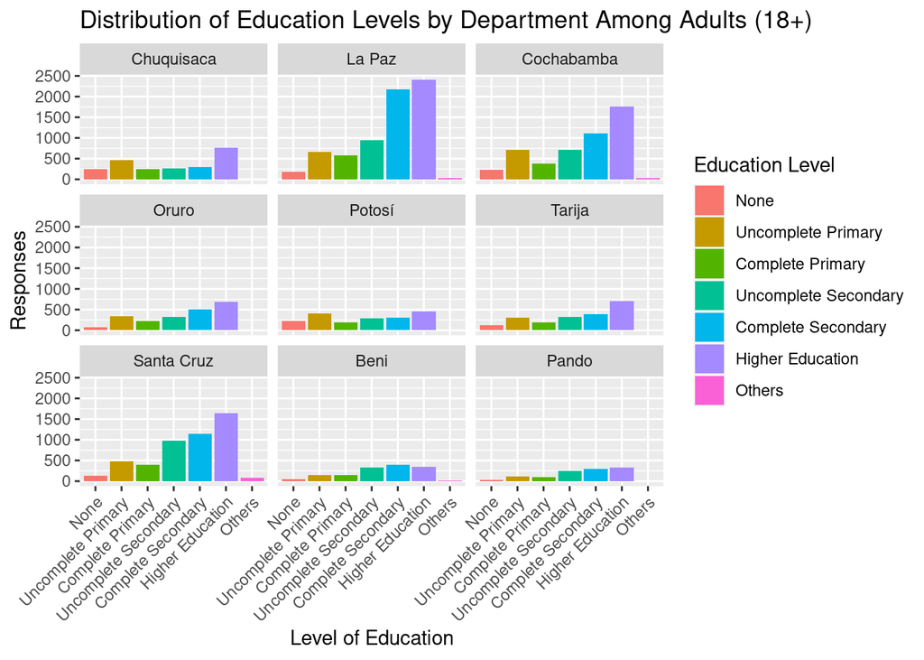

Figure 12: Distribution of Education Levels by Department Among Adults

While raw counts provide a broad overview of the educational landscape in each department, they can sometimes mask underlying patterns. Different departments may have significantly different population sizes, which can influence the raw counts. To gain a more nuanced understanding of the distribution of education levels, it’s crucial to normalize these counts by looking at the percentage distribution within each department. This perspective can reveal relative trends and disparities that might be obscured when looking at raw counts.

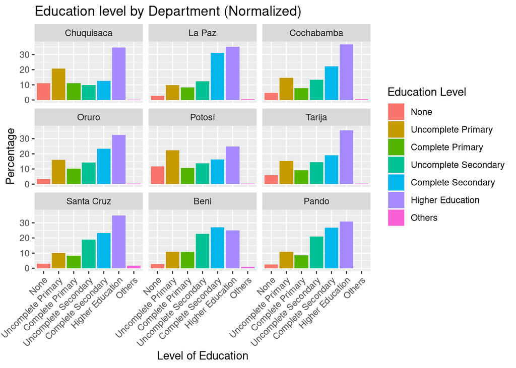

Figure 13: Percentage Distribution of Education Levels by Department Among Adults

#### Labor and Employment

As we continue to unravel the complex tapestry of migration patterns in Bolivia, it’s vital to consider the role of labor and employment. Employment status and occupational categories can significantly influence an individual’s decision to change homes. Economic opportunities, job availability, and the nature of specific occupations might steer people towards urban centers or conversely, anchor them to rural areas.

In this next section, we turn our attention to the employment and occupational landscape among the respondents. We will examine the distribution of employment statuses, delve into the variety of occupations, and explore how these factors might interplay with migration. By shedding light on these labor-related aspects, we aim to gain a more comprehensive understanding of the driving forces behind Bolivian migration patterns.

The upcoming figure presents a distribution plot of the reported occupation types. This visualization provides an overview of the occupational landscape among the respondents, shedding light on the most common and least common industries. By understanding this distribution, we can start to explore the relationship between specific occupations and migration trends.

To begin, let’s look at the counts of the the industry/occupation of the respondents.

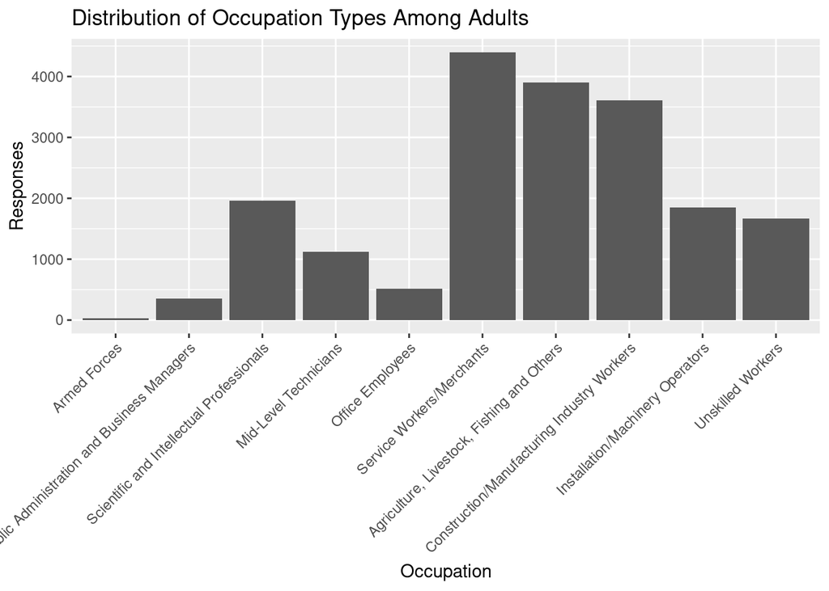

Figure 14: Distribution of Occupation Types Among Adults

Upon examining the distribution of occupation types among adult respondents, we observe a varied landscape. Some occupations, such as ‘Service/Merchant Work’, ‘Agriculture, Hunting, Forestry and Fishing’ and ‘Manufacturing’, are more prevalent among the respondents. These occupations might be more common due to the country’s economic structure and available resources. On the other hand, occupations like ‘Public Administration and Business Management’,‘Office Work’, and ‘Armed Forces’ are less common among respondents, possibly due to the specific skills and qualifications these fields require.

Delving deeper into the occupational distribution, three occupations stand out due to their prevalence among the respondents: Service/Merchants, Agriculture Labor, and Construction/Manufacturing. The Service/Merchants sector represents the largest group, encompassing approximately 22.6% of the respondents. Following closely, Agriculture Labor accounts for around 20.1% of the respondents, and Construction/Manufacturing makes up approximately 18.6%.

These three occupations collectively form a significant portion of the respondents’ occupational landscape, indicating key areas of economic activity among adults in Bolivia. Understanding the labor dynamics within these sectors could provide valuable insights into their potential influence on migratory decisions.

Alongside these prominent occupations, we also see three main types of employment among the respondents. Self-Employment emerges as the most common, accounting for around 44.5% of the respondents. The Worker/Employee category follows, representing approximately 34.1% of the respondents, while Unpaid Family Workers form about 15.5% of the respondents.

In the next figure, we will explore the most common employment types within these top three occupations. This analysis will provide a more nuanced understanding of the labor structures within these prevalent sectors and may reveal specific employment patterns that could play a role in migration trends.

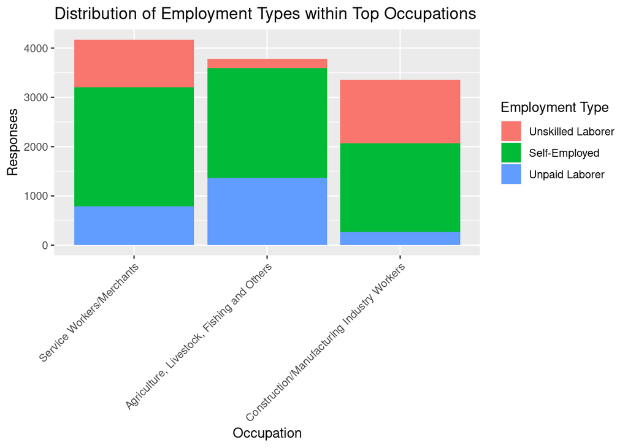

Figure 15: Distribution of Most Common Employment Types within Top Occupations

Upon exploring the employment types within the top three occupations, distinct patterns come to light. The ‘Self-Employed’ category is notably prevalent across all three occupations, suggesting a significant degree of entrepreneurial activity or independent work among these workers.

However, an interesting pattern emerges within the ‘Agriculture Labor’ occupation, where ‘Unpaid Laborers’ make up a substantial portion. Upon reviewing the dataset’s documentation, it’s revealed that this category includes individuals who work on their family-owned land or livestock. This familial or household nature of their work likely accounts for the unpaid aspect of their employment.

Building on this analysis, it would be instructive to examine how these employment type distributions within top occupations might vary across different departments. Such a perspective can uncover regional differences in labor structures and further enrich our understanding of the interplay between labor conditions and migration trends.

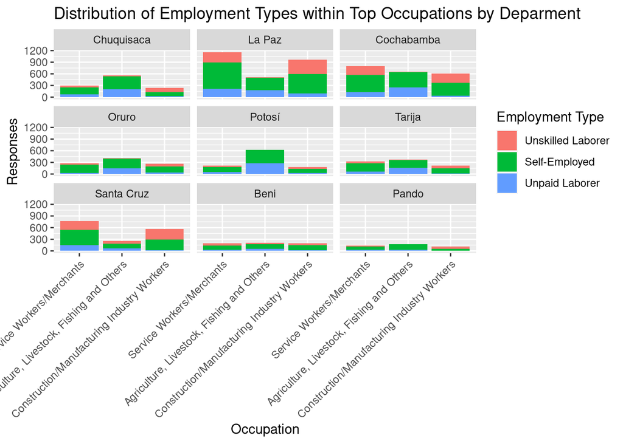

Figure 16: Distribution of Most Common Employment Types within Top Occupations by Department

Upon viewing the employment type distributions within top occupations across different departments, we uncover interesting regional variations. While ‘Self-Employed’ remains a prevalent employment type across all departments, the proportions of ‘Unskilled Laborers’ and ‘Unpaid Laborers’ exhibit notable differences. Some departments, for instance, might have a higher proportion of ‘Unpaid Laborers’ in ‘Agriculture Labor’, reflecting regional variations in family-owned agricultural practices.

These department-wise patterns add another layer of complexity to our understanding of labor structures in Bolivia and their potential influences on migration decisions. They highlight the importance of considering regional contexts when analyzing national labor and migration trends.

With these insights in mind, we turn our attention to the intersection of employment and gender. In the next figure, we will examine the distribution of employment types broken down by sex. This exploration will help us understand if and how gender influences employment patterns in Bolivia, thereby shedding light on another crucial aspect of the migration puzzle.

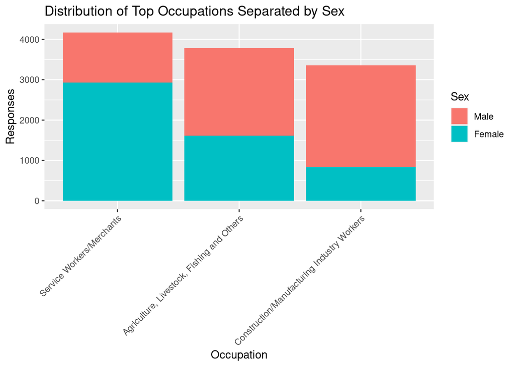

Figure 17: Distribution of Top Occupations Separated by Sex

From the figure, it’s clear that gender distribution varies significantly across the top three occupations. The ‘Service/Merchants’ sector sees a higher proportion of women, indicating their strong presence in service-oriented roles. Meanwhile, ‘Agriculture Labor’ shows a more balanced gender distribution, suggesting relatively equal engagement of men and women in agricultural work. However, ‘Construction/Manufacturing’ is primarily male-dominated, reflecting traditional gender roles in these physically demanding industries.

These insights highlight the role of gender in shaping Bolivia’s labor landscape and potentially influencing migration patterns. Understanding these gender dynamics within specific occupations can provide a deeper perspective on the socioeconomic factors at play in migration decisions.

In the next figure, we’ll explore how these gender distributions within top occupations vary across different departments. This analysis will enable a more granular understanding of regional labor structures, illuminating how gender and occupation intersect at a departmental level.

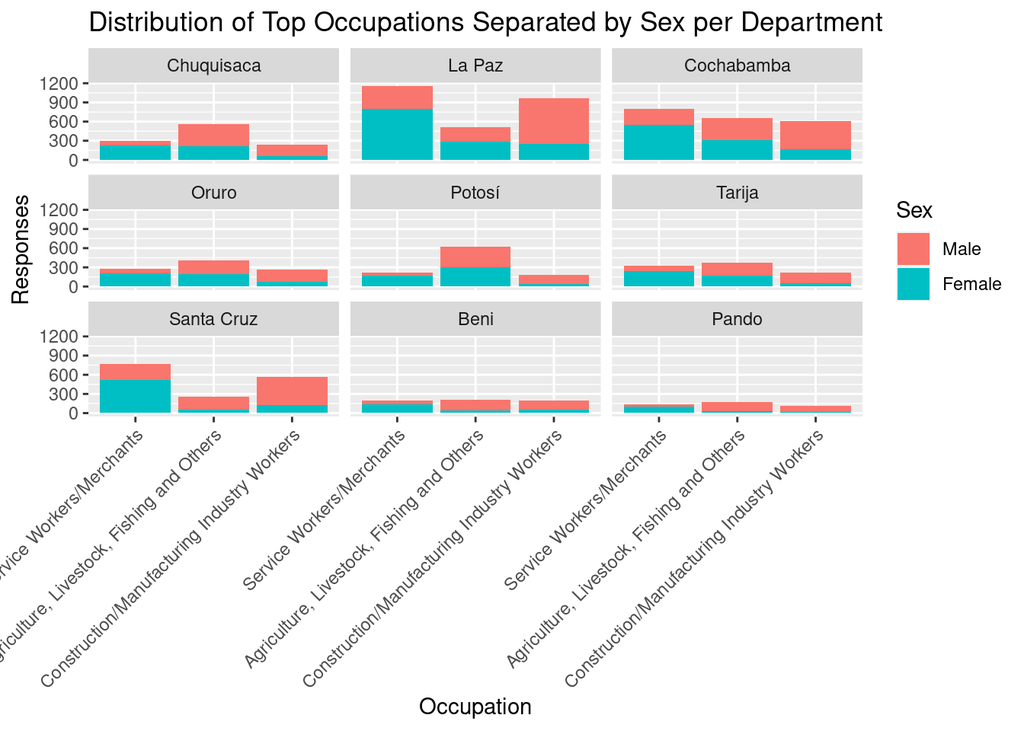

Figure 18: Distribution of Top Occupations Separated by Sex per Department

Upon examining the department-wise gender distributions within top occupations, we observe patterns similar to the overall trends, with some intriguing regional variations. More rural departments, for instance, display a higher proportion of women in the ‘Service/Merchants’ sector compared to ‘Agriculture Labor’ or ‘Construction/Manufacturing’. This could reflect regional economic dynamics, where women might find more opportunities in service-oriented roles.

In contrast, urban departments exhibit a more balanced gender distribution in the ‘Service/Merchants’ sector, although it remains female-dominated. This indicates that urbanization may influence gender roles in the workforce, potentially leading to a more equitable labor landscape.

These insights not only confirm the importance of gender in shaping occupational structures but also highlight the role of regional contexts in influencing these gender dynamics. As we move forward, we’ll delve into another dimension of the labor landscape: age.

In the next table, we will examine the average age of respondents within each occupation. This analysis will help us understand how age distribution varies across occupations, providing another layer of insight into the potential determinants of migration patterns.

Table 1: Average Age per Occupation

| Occupation | Average Age |
| --- | --- |
| Armed Forces | 42.78 |
| Public Administration and Business Managers | 43.29 |
| Scientific and Intellectual Professionals | 41.51 |
| Mid-Level Technicians | 37.38 |
| Office Employees | 34.66 |
| Service Workers/Merchants | 40.25 |
| Agriculture, Livestock, Fishing and Others | 46.53 |
| Construction/Manufacturing Industry Workers | 39.17 |
| Installation/Machinery Operators | 40.25 |
| Unskilled Workers | 37.07 |

Insights from the table reveal interesting age dynamics within various occupations. The ‘Agriculture, Livestock, Fishing and Others’ sector presents the highest average age, suggesting that these fields might be dominated by older workers. Similarly, ‘Armed Forces’ and ‘Public Administration and Business Managers’ also show higher average ages, indicating these occupations might require more experience or seniority.

In contrast, occupations such as ‘Office Employees’, ‘Unskilled Workers’, and ‘Mid-Level Technicians’ have lower average ages, hinting at a younger workforce in these fields. This could be due to a variety of factors, including the level of physical demand, educational requirements, or opportunities for entry-level positions in these sectors.

These age dynamics within specific occupations offer valuable insights into the labor landscape in Bolivia. Understanding how age and occupation intersect can provide a deeper perspective on the socioeconomic factors at play in migration decisions.

Having examined the occupational landscape and its intersection with gender and age, we now turn our attention to another vital aspect of socioeconomic status and a potential influence on migration decisions: income. Income level can significantly impact an individual’s quality of life, access to resources, and mobility options, making it a critical factor to consider in our analysis. In the following section, we will delve into the income data to uncover patterns, disparities, and potential correlations with migration trends in Bolivia.

#### Income

Income is a crucial facet of socioeconomic status, and understanding its distribution and patterns can provide invaluable insights into migration drivers. In this section, we will dissect the income data from multiple angles. We’ll begin by evaluating median incomes, shedding light on the central tendencies of earnings. Subsequently, we will investigate Bolivia’s minimum wages and gauge the count of individuals whose earnings align with or fall below this threshold. Such insights can be particularly illuminating, highlighting potential economic vulnerabilities within the population. Furthermore, a departmental comparison will offer a granular view of regional disparities, emphasizing areas with pronounced economic contrasts. It’s important to note that for the purpose of this analysis, certain changes have been made to the dataset and assumptions formulated to streamline the evaluation process. These modifications ensure a more structured and focused exploration of the income landscape in Bolivia.

##### Income Data Normalization

To conduct a cohesive and comprehensive analysis of income across Bolivia, it was essential to ensure that all income data adhered to a consistent scale. The original dataset presented income data based on diverse pay frequencies, including weekly,bi-weekly, daily, and yearly rates, among others. To address this inconsistency, we undertook a normalization process. We converted all these different frequencies into a standardized monthly income format. This normalization not only facilitated a more straightforward comparison across all data points but also provided a clearer and more immediate understanding of the monthly economic realities faced by respondents. The result is a unified dataset that offers a consistent view of income patterns across the country.

##### Income Analysis

Table 2: Income Range in Bolivian Pesos (Bs.)

| Maximum | Minimum | Median | Mean |
| --- | --- | --- | --- |
| 452400 | 16.67 | 3200 | 5089.52 |

This table presents a comprehensive overview of income statistics for Bolivia. It encompasses key metrics such as the minimum, maximum, median, and mean incomes, offering a holistic view of the nation’s income landscape. Initial observations from the table indicate that both median and mean incomes sit above Bolivia’s legally mandated minimum wage of 2,250 bs. monthly. This is a promising sign, suggesting that a sizable segment of the population earns above the minimum threshold. However, a noteworthy point of concern is the vast disparity between the minimum and maximum incomes, hinting at potential income inequalities within the nation.

The stark contrast between the highest and lowest incomes cannot be ignored. Such a pronounced disparity can be indicative of deep-rooted economic inequalities, with certain sectors or demographics reaping more significant financial rewards than others. To gain a clearer understanding of these disparities and their potential implications, it’s imperative to delve deeper into the data, exploring the factors and contexts that contribute to this vast income range.

To gain a comprehensive understanding of the spread and concentration of incomes in Bolivia, the upcoming figure presents both a histogram and a box plot. The histogram showcases the frequency distribution of respondents’ incomes, offering a visual representation of where most of the population’s income falls. In tandem, the box plot provides a succinct summary of the data’s central tendency, spread, and potential outliers, highlighting the interquartile range and median income. Together, these visual aids not only illustrate the broader economic landscape but also pinpoint specific areas of concentration, disparity, and potential anomalies within the dataset.

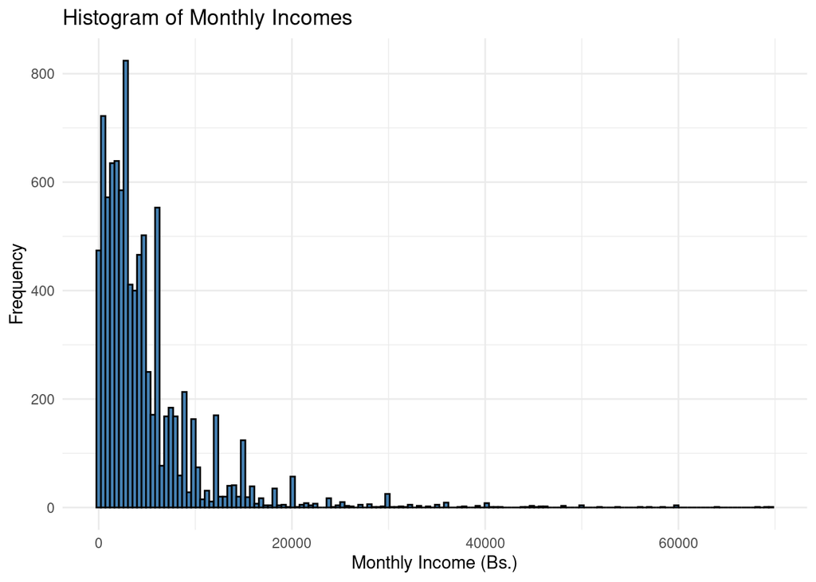

Figure 19: Histogram of Monthly Incomes

From the histogram, it’s evident that a significant portion of the population earns an income that is clustered around a particular range, which appears to be below the 10,000 bs. mark. This concentration suggests that a sizable segment of the population might be earning close to or just above the minimum wage. As income levels increase, fewer individuals fall within those higher brackets, indicating a decreasing prevalence of higher earners.

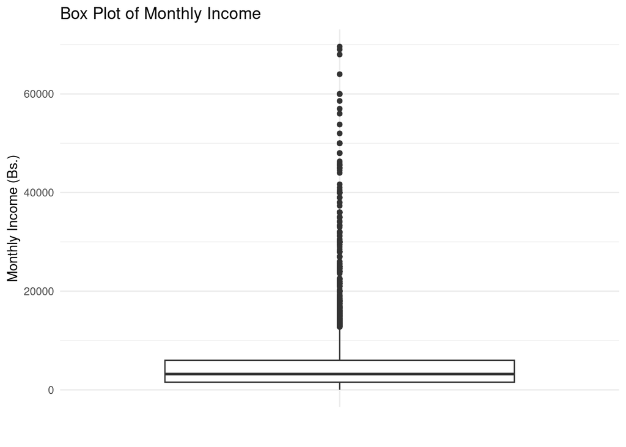

Figure 20: Box Plot of Monthly Incomes

The box plot confirms the observations from the histogram. The median income, indicated by the line inside the box, is situated in the lower income range, reinforcing the idea that a significant proportion of Bolivians earn near the minimum wage. The long whisker and potential outliers suggest that while there are individuals with substantially higher incomes, they are relatively few in number compared to the broader population.

One way to make these visualizations clearer, is by filtering out high-earners. Arbitrarily choosing a 20,000 Bs. limit, which only makes up 2% of the respondents, we find the following plots:

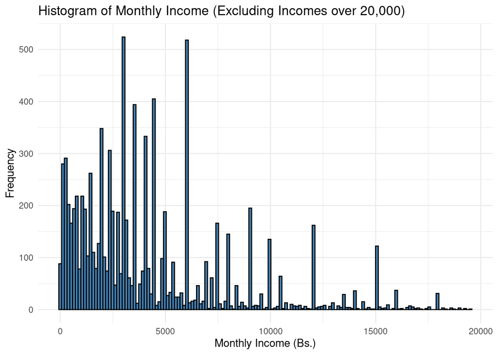

Figure 21: Histogram of Monthly Incomes (Excluding Incomes above 20,000)

The histogram reveals a pronounced peak in the lower income ranges, suggesting that a significant portion of Bolivians earn close to the minimum wage. The concentration of data points in the lower bins further emphasizes the economic challenges faced by many in the country.

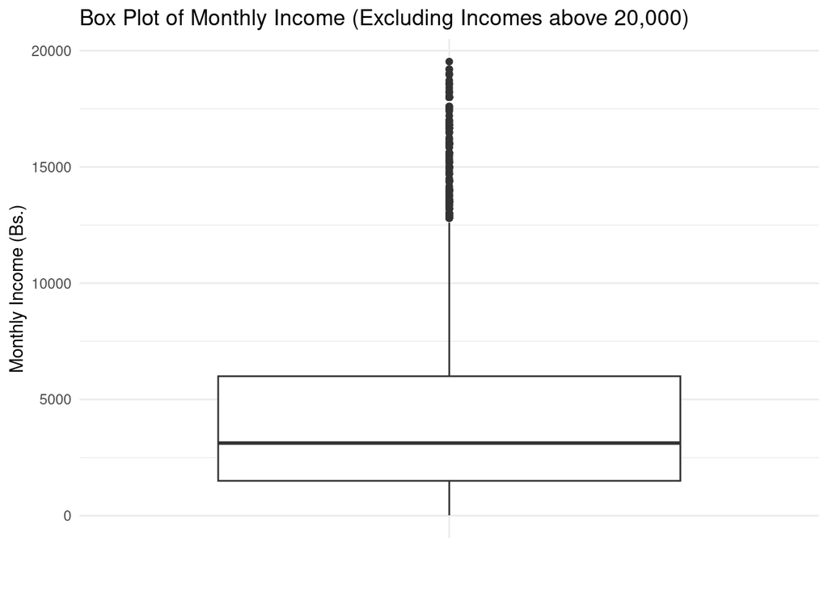

Figure 22: Box Plot of Monthly Incomes (Excluding Incomes above 20,000)

Moving from a holistic view of Bolivia’s income landscape, it’s crucial to delve into regional differences. Bolivia’s diverse departments, each with its unique economic activities and challenges, likely display varied income patterns. The next figure endeavors to shed light on these disparities, presenting the average monthly income for each department.

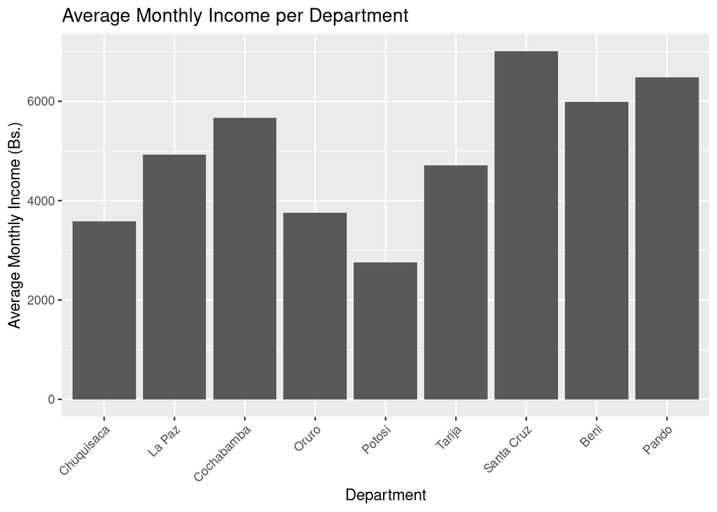

Figure 23: Average Monthly Income by Department

Santa Cruz stands out as the department with the highest average income, closely followed by Beni and Pando, both of which register average mothly incomes above 6,000 bs. This suggests that these regions may have thriving economic sectors or opportunities that elevate the average earnings of their residents. Conversely, Potosi emerges with the most modest average income, hovering just above the national minimum wage. Such disparities underscore the varied economic dynamics at play in different parts of Bolivia and the challenges some regions may face in ensuring economic prosperity for their inhabitants.

Having explored average incomes, it’s imperative to pivot our focus towards a pressing concern: the proportion of individuals earning below the minimum wage. While averages provide an overall perspective, they might sometimes mask underlying challenges. By examining the percentage of individuals earning below the minimum wage across departments, we can identify regions that might be grappling with more profound economic vulnerabilities.

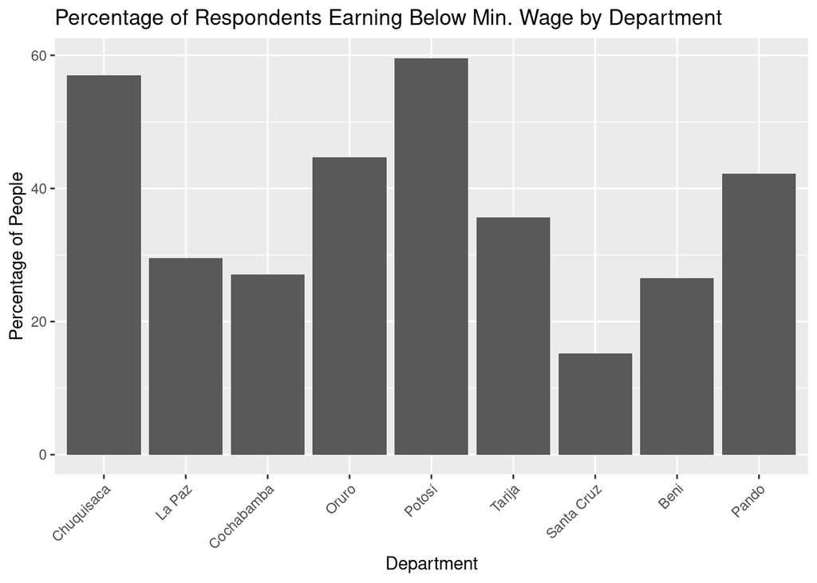

Figure 24: Percentage of Respondents Earning Below Minimum Wage by Department

Santa Cruz emerges as the department with the most promising figures, with less than 20% of respondents earning below the minimum wage. This aligns with its higher average income and suggests a relatively prosperous economic environment. In stark contrast, both Potosi and Chuquisaca display alarming figures, with almost 60% of their populations earning below the threshold. Such high percentages indicate systemic challenges that might be suppressing incomes in these areas. Pando, intriguingly, presents a conundrum. Despite boasting a high average monthly income, almost 40% of its residents earn below the minimum wage. This dichotomy suggests that while some sectors or individuals in Pando might be thriving, a significant portion of the population remains economically vulnerable.

From assessing economic vulnerabilities, we now turn our gaze to the upper echelons of the income spectrum. High earners, those earning above 20,000 bs. per month, can provide insights into the peaks of economic prosperity within Bolivia’s diverse departments. Such an analysis not only offers a glimpse into regions with potentially thriving sectors but also brings to light any juxtapositions in the income landscape.

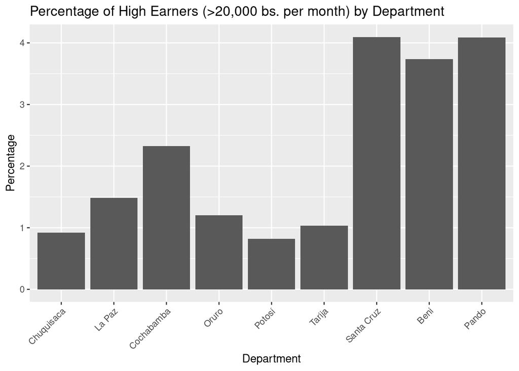

Figure 25: Percentage of High Earners (>20,000 bs. per month) by Department

It’s riveting to note that the majority of individuals earning above 20,000 bs. reside in Santa Cruz, Pando, and Beni. Santa Cruz’s presence in this list aligns with its previous economic indicators, especially its notably low percentage of people living below the minimum wage. However, Pando’s position is a captivating revelation. Despite a significant segment of its population earning below the minimum wage, Pando also hosts a considerable number of high earners. This stark income disparity within Pando suggests the presence of distinct economic sectors or circumstances, with some individuals reaping substantial benefits while others face economic challenges.

##### Summary Conclusion of Income Analysis

Our exploration of incomes in Bolivia has unveiled a multifaceted economic landscape, characterized by both prosperity and challenges. From the national distribution of monthly incomes to the intricate departmental disparities, our insights have shed light on the depth and breadth of Bolivia’s economic dynamics. Santa Cruz consistently emerged as a beacon of economic prosperity, while departments like Potosi and Chuquisaca presented more concerning economic indicators. Pando stood out as an enigma, showcasing both the highs and lows of the economic spectrum within its boundaries. Such disparities underscore the importance of tailored economic policies and interventions that address the unique needs of each region.

As we transition from understanding the economic backdrop, our focus now shifts to the heart of this study: migratory patterns in Bolivia. With a grasp on the economic realities faced by Bolivians, we are better equipped to delve into the nuances of migration, seeking to understand its drivers, trends, and implications.

### Migratory Patterns in Bolivia

After a comprehensive preliminary exploration of Bolivia’s socio-economic fabric, from its educational landscape to its income dynamics, we now dive deep into the main theme of our study: the migratory patterns of Bolivians. Migration is a multifaceted phenomenon, often intertwined with the very socio-economic elements we’ve studied. Whether driven by the pursuit of better opportunities, economic necessities, or personal aspirations, migration shapes and is shaped by the larger narrative of a nation’s growth and challenges.

In this in-depth analysis, we’ll explore multiple facets of migration:

**Migration from Abroad:** Bolivians who sought opportunities beyond national borders provide insights into global aspirations and the international perception of Bolivia’s prospects.

**National Migration:** Delving into internal movements, we aim to understand the regions that are magnets for migration and those that witness significant outflows. Such patterns can highlight areas of economic and social prosperity, as well as regions that might be facing challenges.

**Focus on Santa Cruz:** Given its prominence in our earlier analyses, especially in the economic sphere, a dedicated exploration of migration into Santa Cruz becomes imperative. As a potential hub of opportunity, understanding its allure can provide actionable insights for national policy-making and regional development strategies.

Throughout this analysis, our goal is to weave together the threads of our preliminary findings with the intricate patterns of migration, crafting a holistic narrative of Bolivia’s current socio-economic and migratory landscape.

#### Refresher

In the extensive dataset capturing the voices of Bolivians, it’s pivotal to recall the geographical distribution of our respondents. With a rich mix from departments like La Paz, Santa Cruz, and Cochabamba leading in response count, we have a diverse range of perspectives at our disposal. As we dive into the migratory patterns, a significant preparatory step involved refining our dataset. To truly capture migration nuances, we’ve excluded respondents who haven’t experienced migration, narrowing our focus on those who’ve undergone this transformative journey.

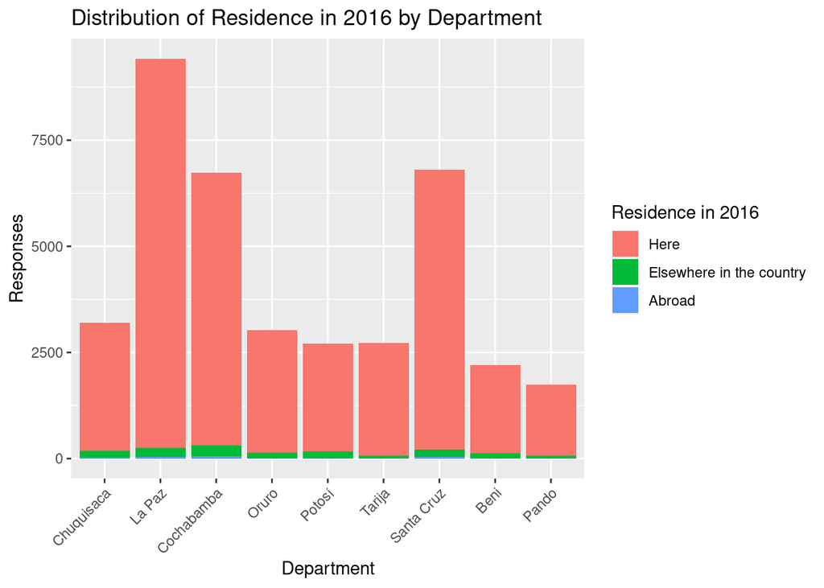

Figure 26: Distribution of Residence in 2016 by Department

Of the robust 42,000 responses we initially had, only 1,564 respondents have actually migrated, underscoring the selective nature of migration and its relative rarity.

Our forthcoming figure delves into this filtered dataset, presenting the distribution of these migrants. Specifically, it differentiates between those who chose national relocation versus those who ventured internationally, offering a primary glimpse into the scales and directions of Bolivian migration.

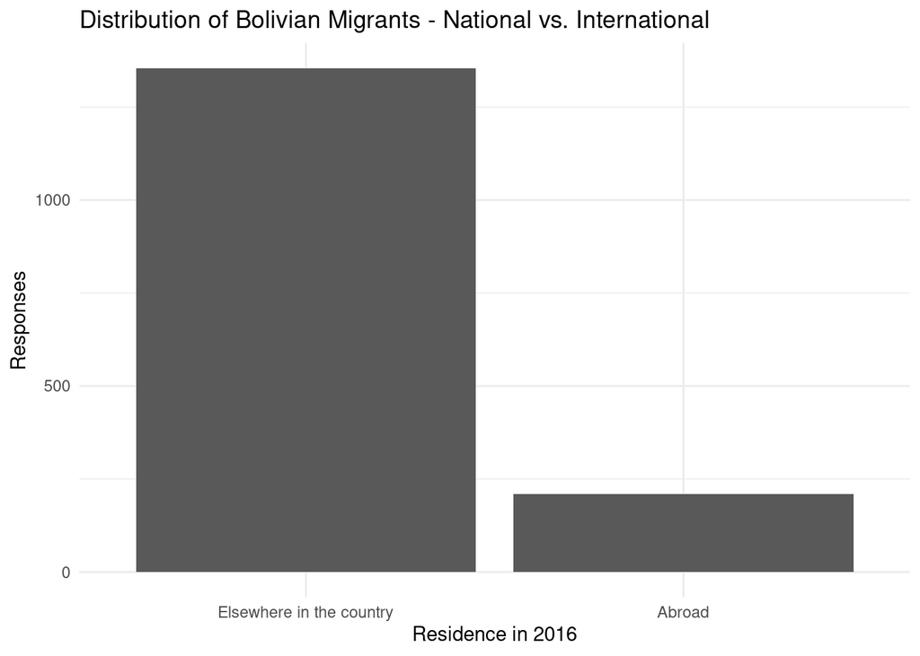

Figure 27: Distribution of Bolivian Migrants - National vs. International

The data elucidates a marked inclination towards national migration since 2016. A considerable majority of Bolivians who’ve moved have done so within the country’s boundaries. The relatively limited number of international returns emphasizes the strength of domestic relocation trends. This might hint at various factors, from economic opportunities in specific departments to socio-cultural ties pulling individuals back to familiar regions within Bolivia. It also sheds light on the dynamics of Bolivians abroad; the limited international returns might suggest either satisfaction with their current international locations or potential barriers to repatriation.

#### Migrants Coming from Abroad

Diving deeper into the migratory patterns, we now turn our attention to Bolivians moving back from abroad since 2016. This aspect of the study provides a unique lens into the global footprint of Bolivians and the push and pull factors influencing their decisions to return home. Whether driven by global economic dynamics, personal reasons, or geopolitical shifts, understanding these patterns can offer valuable insights into Bolivia’s position in the global context.

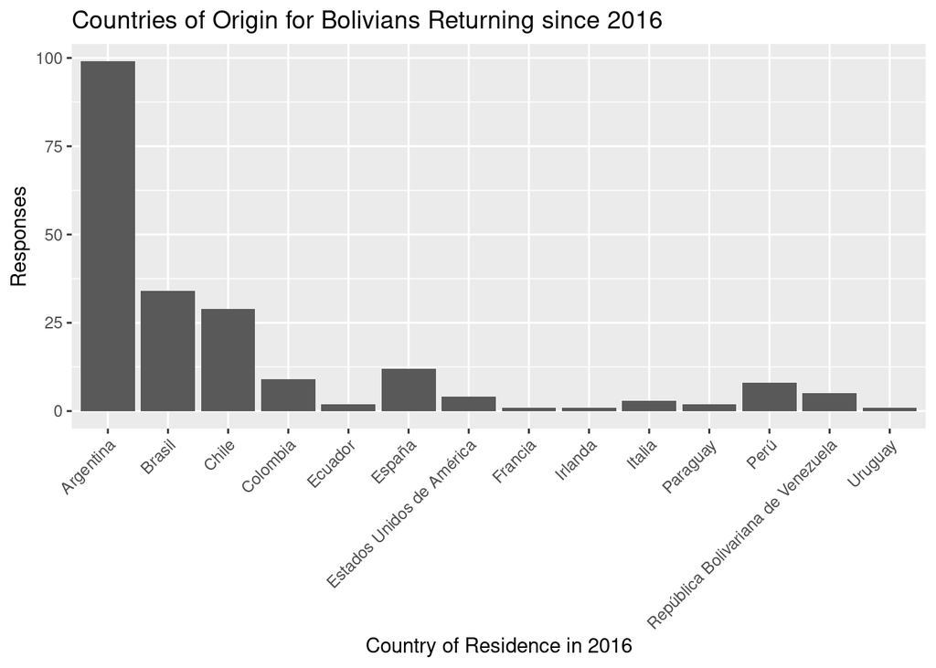

Figure 28: Countries of Origin for Bolivians Returning since 2016

##### Sex of International Migrants

Having understood the geographical origins of returning Bolivians, it’s essential to delve into demographic nuances. One such facet is the gender distribution among these international migrants. This can provide insights into any gender-specific trends or anomalies that might be present within the returning population.

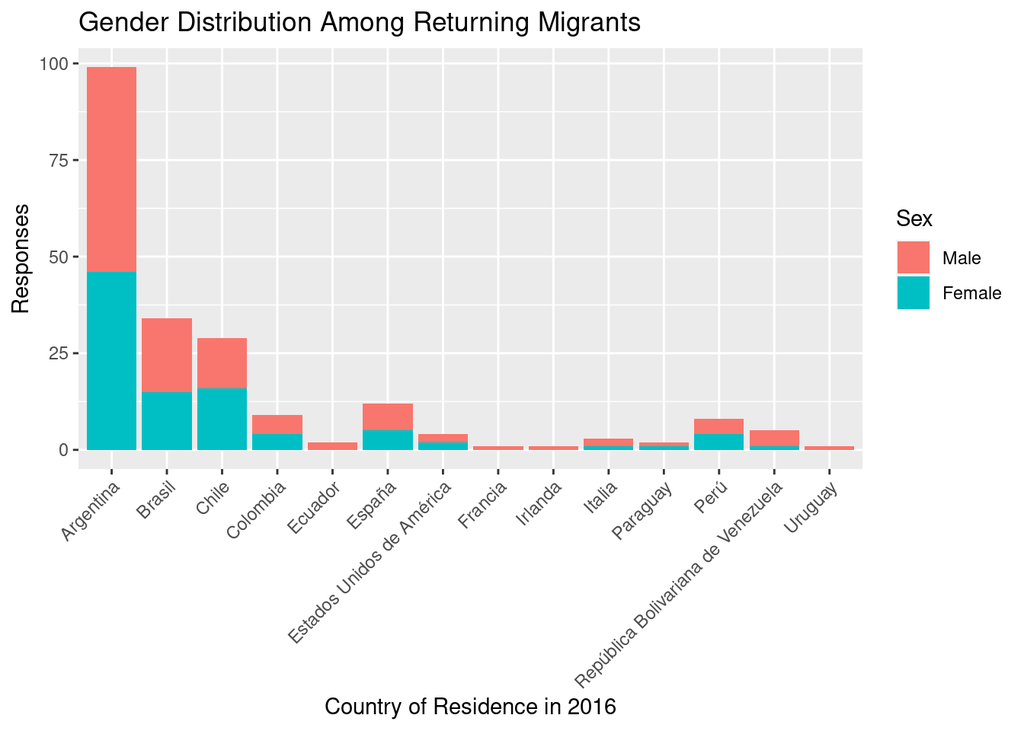

Figure 29: Gender Distribution among Returning Migrants

Overall, there’s a balanced representation of genders among the returning migrants, suggesting that both men and women have comparable motivations or circumstances for repatriation. However, a peculiar observation arises with migrants from France, Ireland, Ecuador, and Uruguay, where 100% of the returnees are male. Given the small numbers, it’s challenging to deduce a concrete reason. One hypothesis could be educational or specific employment opportunities that ended, but without further data, it remains a point of intrigue.

##### Age of International Migrants

After gleaning insights into the gender distribution of returning Bolivians, our focus now shifts to age demographics. Age can serve as a window into the stages of life at which individuals decide to return, revealing motivations ranging from career/education opportunities to familial ties or retirement.

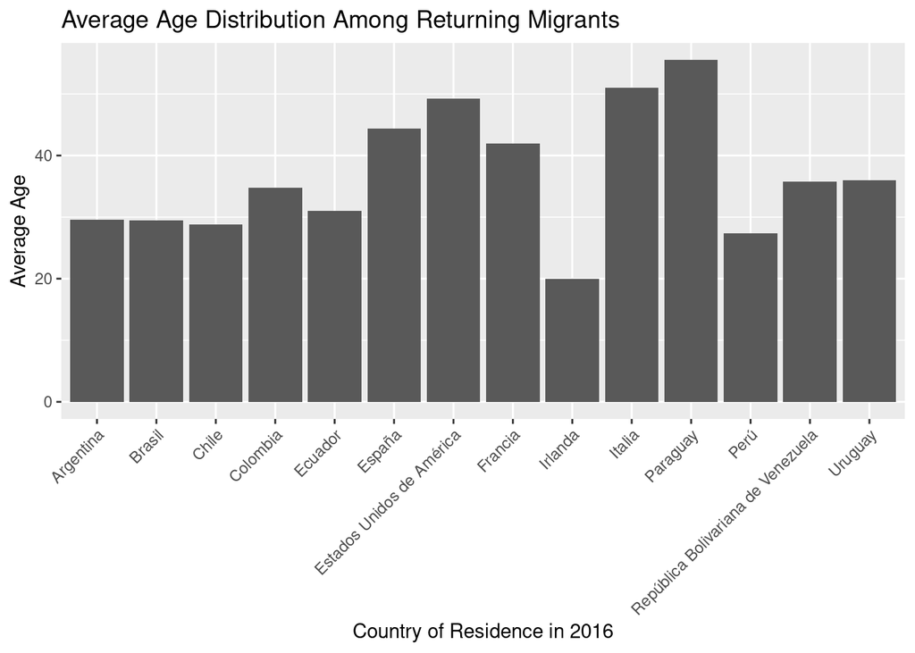

Figure 30: Age Distribution among Returning Migrants

Distinct patterns emerge when examining the average age of returnees. Paraguay, Italy, and the USA stand out with the highest average ages, hovering around the 50-year mark. This might suggest a cohort of individuals returning possibly for retirement or after long-term stays abroad. In contrast, most other countries present an average age around 30 years, indicating a younger demographic of returnees. The youngest group, intriguingly, hails from Ireland, potentially pointing to students or young professionals concluding their overseas endeavors and choosing to return home.

##### Reasons for Repatriation

While age offers a window into the stages of life at which individuals decide to return, the reasons behind these decisions provide deeper insights. Delving into the motivations that drive Bolivians to repatriate can help us understand the pull factors of Bolivia and the push factors from their countries of residence.

Table 3: Top Reasons for Repatriation Among International Migrants

| Country_2016 | Reason | Count |
| --- | --- | --- |
| Argentina | Family Reason | 69 |
| Brasil | Family Reason | 22 |
| Chile | Family Reason | 16 |
| Colombia | Family Reason | 4 |
| Ecuador | Job Search | 1 |
| España | Family Reason | 9 |
| Estados Unidos de América | Family Reason | 4 |
| Francia | Family Reason | 1 |
| Irlanda | Education | 1 |
| Italia | Family Reason | 3 |
| Paraguay | Work Transfer | 1 |
| Perú | Job Search | 4 |
| República Bolivariana de Venezuela | Job Search | 5 |
| Uruguay | Job Search | 1 |

A dominant reason that emerges for repatriation is family-related considerations. This highlights the strong familial and cultural ties that Bolivians maintain, even when abroad. Interestingly, our earlier observation about the younger demographic from Ireland finds validation: education emerges as a significant reason. This suggests that many might have ventured abroad for educational opportunities and upon completion, chose to return to their homeland, reinforcing the idea that Bolivia’s pull remains strong across various life stages and experiences.

##### Labor and Employment of International Migrants

Having understood the motivations behind repatriation, it’s essential to cast a spotlight on the professional lives of these returning Bolivians. The occupations they held while abroad can offer insights into the types of opportunities they sought, the industries they engaged with, and the skills they might be bringing back to Bolivia.

Table 4: Top Occupation of Returning Bolivians

| Country_2016 | Occupation | Count |
| --- | --- | --- |
| Argentina | Service Workers/Merchants | 15 |
| Brasil | Construction/Manufacturing Industry Workers | 8 |
| Chile | Construction/Manufacturing Industry Workers | 7 |
| Colombia | Service Workers/Merchants | 3 |
| Ecuador | Construction/Manufacturing Industry Workers | 2 |
| España | Service Workers/Merchants | 4 |
| Estados Unidos de América | Scientific and Intellectual Professionals | 1 |
| Francia | Construction/Manufacturing Industry Workers | 1 |
| Italia | Mid-Level Technicians | 1 |
| Paraguay | Agriculture, Livestock, Fishing and Others | 1 |
| Perú | Service Workers/Merchants | 2 |
| República Bolivariana de Venezuela | Service Workers/Merchants | 2 |
| Uruguay | Construction/Manufacturing Industry Workers | 1 |

The table offers a segmented view of the occupations held by returning Bolivians based on their country of residence in 2016. Argentina, a leading country of origin for migrants, predominantly features returnees now in the service and merchant sectors. Similarly, service roles are also a common occupation for Bolivians returning from Colombia, Spain, Peru, and Venezuela.

Interestingly, Brazil, Chile, France, and Uruguay highlight a trend towards the construction and manufacturing industries. This suggests that Bolivians in these countries were actively engaged in hands-on, industry-driven roles. A noteworthy mention is the United States, where the sole respondent was involved in a scientific and intellectual profession, while Italy saw a returnee from a mid-level technician role. Paraguay’s lone respondent was engaged in agriculture, livestock, or fishing.

These insights underscore the diverse range of industries and roles Bolivians immerse themselves in while abroad, reflecting both the opportunities available in these countries and the versatile skills of the Bolivian diaspora.

##### Income of Returning Bolivians

Having unraveled the professional trajectories of returning Bolivians, we now turn to a pivotal aspect of their post-migration experience: their economic standing in Bolivia. By understanding their current financial situation, we can gauge the economic impact of their time spent abroad and determine if their international experiences have translated into tangible economic benefits upon their return.

Table 5: Average Monthly Income (Bs.) of Returning Bolivians by Country of Origin

| Country | Average Monthly Income (Bs.) |
| --- | --- |
| Argentina | 3672.65 |
| Brasil | 5458.33 |
| Chile | 16592.73 |
| Colombia | 2600.00 |
| España | 17793.33 |
| Estados Unidos de América | 3450.00 |
| Francia | 4500.00 |
| Italia | 15500.00 |
| Paraguay | 16666.67 |
| Perú | 13625.00 |

The table furnishes intriguing insights into the financial trajectory of Bolivians post their international sojourns. Spain and Paraguay stand out, with returnees from these countries currently earning higher average monthly incomes in Bolivia. This is closely trailed by those from Chile and Italy. In contrast, returnees from Colombia and Argentina currently report more modest earnings, validated partially by the occupations previously held.

Such disparities raise pertinent questions: Did the international exposure in countries like Spain and Paraguay equip Bolivians with skills or experiences that are particularly valued in Bolivia’s job market? Alternatively, did the socio-economic conditions of their host countries influence their aspirations and career choices upon return? While these figures offer a starting point, they also underscore the multifaceted nature of economic mobility and the myriad factors influencing it. It’s a compelling argument for the potential benefits of international exposure, though a deeper dive would be needed to draw concrete conclusions.

##### Geographic Resettlement of Repatriates in Bolivia

Having delved into the economic trajectories of returning Bolivians, we now shift our focus to their geographic resettlement within Bolivia. By identifying which departments these repatriates chose to settle in, we can uncover patterns and perhaps discern underlying motivations related to their countries of origin.

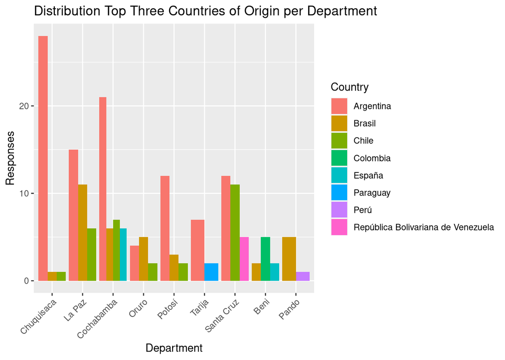

Figure 31: Distribution of Top Three Countries of Origin by Current Department in Bolivia

##### Summary Conclusion of Migration from Abroad Analysis

The exploration of Bolivian repatriates offers a multifaceted view into the lives of those who ventured abroad and then made the conscious decision to return. Through our analysis, several salient points emerge:

**Occupational Landscape:** Bolivians abroad predominantly found themselves in the service, retail, and construction/manufacturing sectors. Such a distribution suggests that many Bolivians abroad might have been involved in roles that required direct interaction or hands-on skills, reflecting the industries where Bolivians found the most success or demand.

**Economic Outcomes:** Upon return, there’s evidence of diverse economic trajectories. Notably, those who returned from Spain and Paraguay are currently enjoying higher average incomes in Bolivia, potentially signifying that experiences in certain countries might have equipped returnees with skills or experiences that are valued in Bolivia’s job market.

**Geographic Resettlement:** The patterns of resettlement within Bolivia post-return are intriguing. Proximity seems to play a role, as seen with the influx of Argentine returnees to Chuquisaca. Yet, other patterns, such as the European returnee concentration in Cochabamba and the distinct Chilean and Brazilian returnee patterns in Santa Cruz and La Paz, respectively, suggest a blend of economic, cultural, and personal factors at play.

**Demographic Trends:** The gender distribution among returnees is generally balanced, though certain countries of origin, like France and Ireland, showed anomalies. Age-wise, the spectrum is wide, with countries like Paraguay, Italy, and the USA having older returnees, while others, notably Ireland, had a notably younger demographic.

In essence, the journey of Bolivians abroad and their subsequent return is a tapestry of experiences, influenced by a myriad of factors ranging from economic aspirations to personal motivations. As Bolivia continues to evolve, understanding these patterns and the insights they offer can be instrumental in shaping policies and fostering an environment that resonates with the aspirations and needs of its returning diaspora.

#### Migration within Bolivia

Migration, while often considered in international contexts, also has significant domestic dimensions. Within the expansive and diverse landscapes of Bolivia, individuals and families move between departments, seeking opportunities, better living conditions, or sometimes just a change. As we delve into the national migration patterns of Bolivia, we aim to uncover the intricate dance of population shifts between its various departments.

A key aspect of this section will be an analysis of the net migratory changes across each department. By examining these shifts, we can gain insights into which regions are burgeoning hubs of attraction and which might be experiencing outflows. Such patterns can offer a wealth of information on the socio-economic and cultural dynamics at play within Bolivia’s borders.

**NOTE:** It’s crucial to highlight that while the dataset also captures movements within departments, i.e., from one municipality to another, such intra-departmental shifts are not the focus of this analysis and will be filtered out to provide a clearer perspective on broader migratory trends.

With this context in place, let’s embark on our journey through Bolivia’s internal migration landscape.

##### Current Destinations of Internal Migrants

As we embark on understanding the internal migration patterns within Bolivia, a fundamental question arises: Where are people migrating to? By identifying the current department of residence of migrants, we can discern which regions are the most attractive or promising for Bolivians on the move.

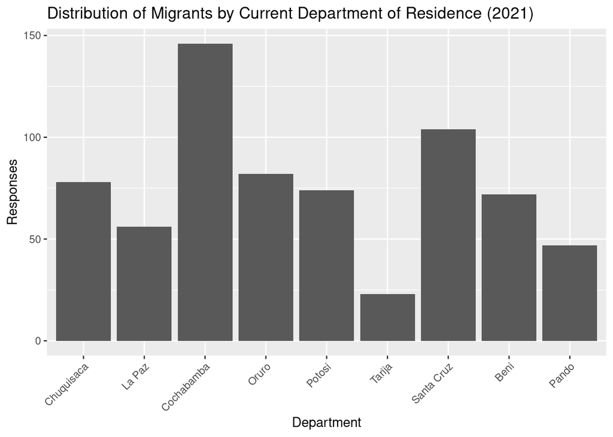

Figure 32: Distribution of Migrants by Current Department of Residence (2021)